# dual ISC development v2 - falling in love with nest

## Design for 1 taskrun of 1 sub

### Select 1 sub/task/run

```r
library(dplyr)
```

```r
library(tidyr)
library(purrr)
library(stringr)
library(RNifti)
library(tictoc)
library(ggplot2)
options(digits = 3)

# Immutable parameters
gitdir <- "/data00/layerfMRI/Github_repo/"
bd <- paste0(gitdir,"layerfMRI/analyses/dual_ISC/")
regdatadir <- "/data00/layerfMRI/regdata/"
depthdatadir <- paste0(bd, "/data_native/")


# load the logs and do some adjustment to names of columns and observations
df <- read.csv("log_summary.csv") %>%
  arrange(subject,session,task,run) %>%
  select(-c(Trial,Event.Type,Time,NMov)) %>%
  mutate(sub = sprintf("sub_%02d",subject) ) %>%
  select(-subject) %>%
  mutate(ses = sprintf("ses_%02d", session) ) %>%
  select(-session) %>%
  mutate(contrast = ifelse(Type == "M", "thresh_zstat1.nii.gz", "thresh_zstat2.nii.gz") ) %>%
  select(-c(Type, total_TR, Duration) ) %>%
  rename(muvi = Title)



# limit to one subject/run/contrast for development
nsub <- "sub_02"
nses <- "ses_01"  # because it's in the filename of the 4D file
ntask <- 1
nrun <- 1
ncontrast <- "thresh_zstat1.nii.gz"

df <- df %>%
  filter(sub == nsub, ses == nses, task == ntask, run == nrun, contrast == ncontrast)

df
```

```
##   start_TR end_TR             muvi task run    sub    ses             contrast
## 1       42     54    M1ballonD.avi    1   1 sub_02 ses_01 thresh_zstat1.nii.gz
## 2       77     96 M3breakfastD.avi    1   1 sub_02 ses_01 thresh_zstat1.nii.gz
## 3      121    138 M6cigaretteD.avi    1   1 sub_02 ses_01 thresh_zstat1.nii.gz
## 4      171    190   M7flowersD.avi    1   1 sub_02 ses_01 thresh_zstat1.nii.gz
## 5      193    220     M8frameD.avi    1   1 sub_02 ses_01 thresh_zstat1.nii.gz
```

### Load images

And get idx as well as the corresponding JU and D.

Note that this is subject/taskrun/contrast specific!

```r
fmri4D <- paste0(regdatadir,"/",nsub,"/",nses,"/func/task_",ntask,"_run_",nrun,"_4D.nii.gz") %>% readNifti()
fmri2D <- matrix(fmri4D, nrow = prod(dim(fmri4D)[1:3]), ncol = dim(fmri4D)[4])

JU_nii <- paste0(depthdatadir,"/",nsub,"/atlas/",nsub,"_atlas_task_",ntask,"_run_",nrun,".nii.gz") %>% readNifti()
D_nii  <- paste0(depthdatadir,"/",nsub,"/depth/",nsub,"_depth_task_",ntask,"_run_",nrun,".nii.gz") %>% readNifti()
Z_nii  <- paste0(depthdatadir,"/",nsub, "/Zstat/", "task_",ntask,"_run_",nrun,"/thresh_zstat1.nii.gz") %>% readNifti()
```

### Get idx of >zthr voxels, group_by JU and bin

Note that this is subject/taskrun/contrast specific!

```r
zthr <- 2.3            # in the ISC results this will likely be a 0/1 logical
nbin <- 10              # define numba of bins
clusterSizeThr <- 200   # we don't want to consider JU ROIs with only 2 >zthr voxels


get_Z_D_JU_vals <- function(zthr, Z_nii, D_nii, JU_nii) {

  # Create an index of sig voxels, i.e. whose value is > zthr
  Zthr_idx <- which(Z_nii > zthr)

  # Extract Z, D, JU values at the location of Zthr_idx
  Z <- Z_nii[Zthr_idx]
  D <- D_nii[Zthr_idx]
  JU <- JU_nii[Zthr_idx]

  # Purrr everything into a list of tibbles and retain only D,Z values
  # inside JU ROIs
  vals <- tibble(Zthr_idx, Z, D, JU) %>%
    rename(idx = Zthr_idx) %>%
    filter(JU > 0)

  return(vals)
}

df_idx <- get_Z_D_JU_vals(zthr, Z_nii, D_nii, JU_nii)
df_idx
```

```
## # A tibble: 3,172 x 4
##       idx     Z     D    JU
##     <int> <dbl> <dbl> <dbl>
##  1 505308  3.60 0.904    31
##  2 505337  2.86 0.786    31
##  3 505338  2.54 0.731    31
##  4 505367  3.37 0.589    31
##  5 512086  2.37 0.718    31
##  6 518777  2.64 0.906    31
##  7 518778  2.33 0.716    31
##  8 518806  4.89 0.863    31
##  9 525497  3.56 0.796    31
## 10 525498  2.36 0.764    31
## # … with 3,162 more rows
```

```r
# for each bin in each JU ROI > clusterSizeThr, get the idx of the voxels
df_idx <- df_idx %>%
  group_by(JU) %>%                    # 1. group_by JU ROI
  mutate(nvox = n()) %>%              # 2. count numba vox in each JU ROI
  arrange(nvox, JU) %>%               # sort by ascending nvox, just to check
  filter(nvox > clusterSizeThr) %>%   # 3. remove JU with nvox < clusterSizeThr
  mutate(D_bins = findInterval(D, seq(0, 1, by=1/nbin))) %>% arrange(JU,D_bins) %>%  # 4. assign to bins
  group_by(JU,D_bins) %>%             # 5. group by JU and bins, to have separate rows in the end
  summarise(                          # 6. create a column where each cell has a list with the idx of sig voxels
    idx_voxels = list(idx),
    .groups = "drop"
  )

df_idx
```

```
## # A tibble: 60 x 3
##       JU D_bins idx_voxels
##    <dbl>  <int> <list>
##  1    13      1 <int [11]>
##  2    13      2 <int [25]>
##  3    13      3 <int [38]>
##  4    13      4 <int [47]>
##  5    13      5 <int [55]>
##  6    13      6 <int [76]>
##  7    13      7 <int [70]>
##  8    13      8 <int [69]>
##  9    13      9 <int [78]>
## 10    13     10 <int [18]>
## # … with 50 more rows
```

# really? I need to inject the whole df_idx for each row of df?

fuck yeah!!! :O) finally I got it!

```r
# test here
mov <- tibble(muvi = c("muvi_1","muvi_2","muvi_3")) %>% mutate(shebang = list(df_idx))
mov %>% unnest(shebang)
```

```
## # A tibble: 180 x 4
##    muvi      JU D_bins idx_voxels
##    <chr>  <dbl>  <int> <list>
##  1 muvi_1    13      1 <int [11]>
##  2 muvi_1    13      2 <int [25]>
##  3 muvi_1    13      3 <int [38]>
##  4 muvi_1    13      4 <int [47]>
##  5 muvi_1    13      5 <int [55]>
##  6 muvi_1    13      6 <int [76]>
##  7 muvi_1    13      7 <int [70]>
##  8 muvi_1    13      8 <int [69]>
##  9 muvi_1    13      9 <int [78]>
## 10 muvi_1    13     10 <int [18]>
## # … with 170 more rows
```

```r
# real deal here
pf <- df %>%
  mutate(shebang = list(df_idx) ) %>%
  unnest(shebang)

pf
```

```
## # A tibble: 300 x 11
##    start_TR end_TR muvi   task   run sub   ses   contrast    JU D_bins
##       <int>  <int> <fct> <int> <int> <chr> <chr> <chr>    <dbl>  <int>
##  1       42     54 M1ba…     1     1 sub_… ses_… thresh_…    13      1
##  2       42     54 M1ba…     1     1 sub_… ses_… thresh_…    13      2
##  3       42     54 M1ba…     1     1 sub_… ses_… thresh_…    13      3
##  4       42     54 M1ba…     1     1 sub_… ses_… thresh_…    13      4
##  5       42     54 M1ba…     1     1 sub_… ses_… thresh_…    13      5
##  6       42     54 M1ba…     1     1 sub_… ses_… thresh_…    13      6
##  7       42     54 M1ba…     1     1 sub_… ses_… thresh_…    13      7
##  8       42     54 M1ba…     1     1 sub_… ses_… thresh_…    13      8
##  9       42     54 M1ba…     1     1 sub_… ses_… thresh_…    13      9
## 10       42     54 M1ba…     1     1 sub_… ses_… thresh_…    13     10
## # … with 290 more rows, and 1 more variable: idx_voxels <list>
```

## Prepare df to receive the mean time courses for each bin

We need to get for each muvi one mean time course for each bin of each JU ROI. We could do it by nesting lists, but it would probably be very complex and not easy to read (as well as write to csv).

The easiest way is to use a trick: we prepare for each movie nJU*nbin rows, where nJU is the numba of JU ROIs where there are sig voxels, and nbin is the number of bins.

The magic is done by creating a new column filled with lists, and then unnesting it. This has to be done (1) for the bins and (2) for the JU ROI **in this order!** since there are nbins for each JU ROI.

Now for the really cool bit: of course there are *not* sig voxels in all ROIs. Just after we create the extra rows in df, we will retain only those in which there are sig voxels using the info from df_idx!

```r
# read the table with the names of JU ROI and remove WM regions
julabels <- read.csv("labels_juelich.csv", stringsAsFactors = F) %>%
  mutate(name = str_replace(name,"['-/]","")) %>%    # get rid of special chars
  mutate(numba = index + 1) %>%
  filter(grepl("GM", name)) %>%
  select(-index)


df_BIG <- df %>%
  mutate(bin = list(1:nbin)) %>%
  unnest(bin) %>%
  mutate(JU = list(julabels)) %>%
  unnest(JU) %>%
  rename(JU_name = name, JU_numba = numba) %>%
  relocate(bin, JU_numba, muvi)

# create an index of JU ROIs where there are sig voxels, to retain only the necessary
# rows in df_BIG
sig_JU <- df_idx %>% distinct(JU) %>% pull()

df_BIG <- df_BIG %>%
  filter(JU_numba %in% sig_JU) %>%
  arrange(JU_numba)

df_BIG
```

```
## # A tibble: 300 x 11
##      bin JU_numba muvi  start_TR end_TR  task   run sub   ses   contrast JU_name
##    <int>    <dbl> <fct>    <int>  <int> <int> <int> <chr> <chr> <chr>    <chr>
##  1     1       13 M1ba…       42     54     1     1 sub_… ses_… thresh_… GM_Bro…
##  2     2       13 M1ba…       42     54     1     1 sub_… ses_… thresh_… GM_Bro…
##  3     3       13 M1ba…       42     54     1     1 sub_… ses_… thresh_… GM_Bro…
##  4     4       13 M1ba…       42     54     1     1 sub_… ses_… thresh_… GM_Bro…
##  5     5       13 M1ba…       42     54     1     1 sub_… ses_… thresh_… GM_Bro…
##  6     6       13 M1ba…       42     54     1     1 sub_… ses_… thresh_… GM_Bro…
##  7     7       13 M1ba…       42     54     1     1 sub_… ses_… thresh_… GM_Bro…
##  8     8       13 M1ba…       42     54     1     1 sub_… ses_… thresh_… GM_Bro…
##  9     9       13 M1ba…       42     54     1     1 sub_… ses_… thresh_… GM_Bro…
## 10    10       13 M1ba…       42     54     1     1 sub_… ses_… thresh_… GM_Bro…
## # … with 290 more rows
```

## Function to extract the mean TC given fmri2D, idx, start_TR and end_TR

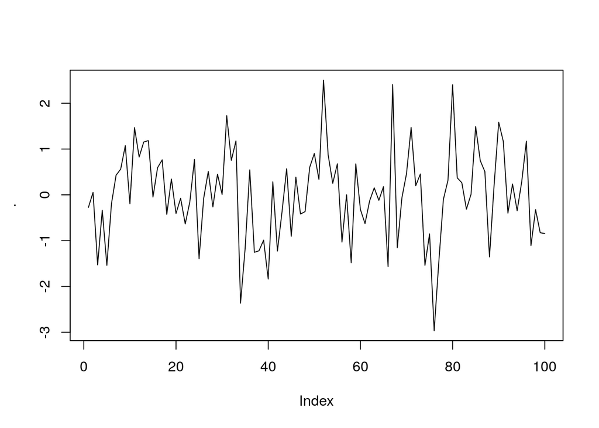

```r
get_mean_tc <- function(fmri2D, idx, start_TR, end_TR) {

  tcs_at_idx_voxels <- fmri2D[idx, start_TR:end_TR]
  zscore <- function(x, na.rm = T) (x - mean(x, na.rm = na.rm)) / sd(x, na.rm)
  tcs_mean <- apply(tcs_at_idx_voxels, MARGIN = 2, mean) %>% zscore()

}


idx <- df_idx$idx_voxels[[1]]
start_TR <- 0
end_TR <- 100

idx_tcs <- fmri2D[idx, start_TR:end_TR]

get_mean_tc(fmri2D, idx, start_TR = 0, end_TR = 100) %>% plot(type='l')
```

```r
df
```

```
##   start_TR end_TR             muvi task run    sub    ses             contrast
## 1       42     54    M1ballonD.avi    1   1 sub_02 ses_01 thresh_zstat1.nii.gz
## 2       77     96 M3breakfastD.avi    1   1 sub_02 ses_01 thresh_zstat1.nii.gz
## 3      121    138 M6cigaretteD.avi    1   1 sub_02 ses_01 thresh_zstat1.nii.gz
## 4      171    190   M7flowersD.avi    1   1 sub_02 ses_01 thresh_zstat1.nii.gz
## 5      193    220     M8frameD.avi    1   1 sub_02 ses_01 thresh_zstat1.nii.gz
```

## dunno if it’s correct after this point

since I don’t recall what was poppa

```r
poppa <- df_idx
```

```r
idx
```

```
##  [1] 695780 702439 709159 782936 789563 789595 789626 789774 843261 870297
## [11] 876956
```

```r
df %>%
  filter(contrast == "thresh_zstat1.nii.gz") %>%
  rowwise() %>%
  mutate(tc = get_mean_tc(fmri2D, poppa$lidx[[1]], start_TR, end_TR) %>% list() )
```

```
## # A tibble: 5 x 9
## # Rowwise:
##   start_TR end_TR muvi          task   run sub    ses   contrast        tc
##      <int>  <int> <fct>        <int> <int> <chr>  <chr> <chr>           <list>
## 1       42     54 M1ballonD.a…     1     1 sub_02 ses_… thresh_zstat1.… <dbl [1…
## 2       77     96 M3breakfast…     1     1 sub_02 ses_… thresh_zstat1.… <dbl [2…
## 3      121    138 M6cigarette…     1     1 sub_02 ses_… thresh_zstat1.… <dbl [1…
## 4      171    190 M7flowersD.…     1     1 sub_02 ses_… thresh_zstat1.… <dbl [2…
## 5      193    220 M8frameD.avi     1     1 sub_02 ses_… thresh_zstat1.… <dbl [2…
```

## Just to see how big this crap is

```r
shebang <- tibble(
  taskrun = c("task1_run1","task1_run2",
              "task2_run1","task2_run2",
              "task3_run1","task3_run2",
              "task4_run1","task4_run2")
) %>%
  mutate(contrast = list(c("thresh_zstat1","thresh_zstat2"))) %>% unnest(contrast) %>%
  mutate(movie = list(map_chr(1:10, ~ paste("movie_", .x))) ) %>% unnest(movie) %>%
  mutate(JU = list(map_chr(1:5, ~ paste("BA_", .x)  ))) %>%  unnest(JU) %>%
  mutate(bin = list(1:10)) %>% unnest(bin)

shebang
```

```
## # A tibble: 8,000 x 5
##    taskrun    contrast      movie    JU      bin
##    <chr>      <chr>         <chr>    <chr> <int>
##  1 task1_run1 thresh_zstat1 movie_ 1 BA_ 1     1
##  2 task1_run1 thresh_zstat1 movie_ 1 BA_ 1     2
##  3 task1_run1 thresh_zstat1 movie_ 1 BA_ 1     3
##  4 task1_run1 thresh_zstat1 movie_ 1 BA_ 1     4
##  5 task1_run1 thresh_zstat1 movie_ 1 BA_ 1     5
##  6 task1_run1 thresh_zstat1 movie_ 1 BA_ 1     6
##  7 task1_run1 thresh_zstat1 movie_ 1 BA_ 1     7
##  8 task1_run1 thresh_zstat1 movie_ 1 BA_ 1     8
##  9 task1_run1 thresh_zstat1 movie_ 1 BA_ 1     9
## 10 task1_run1 thresh_zstat1 movie_ 1 BA_ 1    10
## # … with 7,990 more rows
```

```r
library(collapsibleTree)
collapsibleTree(shebang, c("taskrun","contrast","movie","JU","bin"), collapsed = T, zoomable = F)
```

[interactive chart not shown]

## Garbage collector

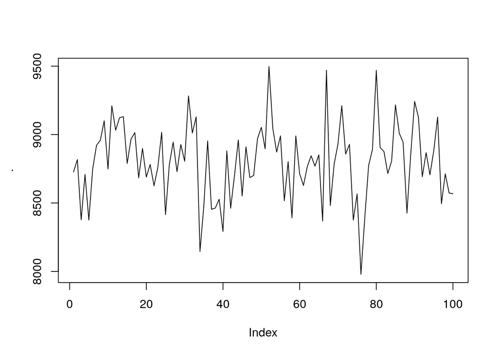

```r
# Quick plot of all/mean tcs for a given bin
apply(idx_tcs, MARGIN = 2, mean) %>% plot(type='l')
```

```r
zscore <- function(x, na.rm = T) (x - mean(x, na.rm = na.rm)) / sd(x, na.rm)


library(tibble)
```

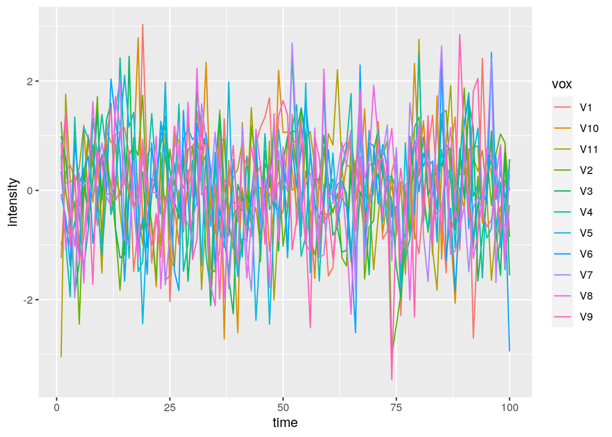

```r
idx_tcs %>% t() %>% as.tibble() %>%
  mutate_all(zscore) %>%
  mutate(time = 1:nrow(.)) %>%
  pivot_longer(cols = starts_with("V"), names_to = "vox", values_to = "intensity") %>%
  arrange(vox) %>%
  ggplot() +
    geom_line(aes(x = time, y = intensity, color = vox))
```